# Machine Learning Project on Dumbell Usage

Bassem Taha

February 5, 2017

#### Overview

In this project, we will use data from accelerometers on the belt, forearm, arm, and dumbell of 6 participants who were asked to perform barbell lifts in 5 different ways as follow:

- correct performance per specification (Class A)
- throwing the elbows to the front (Class B)
- lifting the dumbbell only halfway (Class C)
- lowering the dumbbell only halfway (Class D)
- throwing the hips to the front (Class E).

The goal of this project is to predict the manner in which the 6 participants did the exercise.

#### Libraries

```r
# Libraries
library(knitr)
library(caret)
library(rpart)
library(plyr)
library(dplyr)
library(gbm)
library(rattle)
library(randomForest)
```

#### Data Processing

Load the following training & testing datasets:

[pml-testing] (https://d396qusza40orc.cloudfront.net/predmachlearn/pml-testing.csv)

[pml-training] (https://d396qusza40orc.cloudfront.net/predmachlearn/pml-training.csv)

```r
download.file(url = "https://d396qusza40orc.cloudfront.net/predmachlearn/pml-testing.csv", destfile = "pml-testing.csv")
download.file(url = "https://d396qusza40orc.cloudfront.net/predmachlearn/pml-training.csv", destfile = "pml-training.csv")
# read datasets
training <- read.csv("pml-training.csv", na.strings = c("NA", ""))
testing <- read.csv("pml-testing.csv", na.strings = c("NA", ""))
```

##### Datasets exploration and Cleaning

Data from the training dataset indicate that 100 columns have “NA” & spaces and columns 1:7 (i.e timestamp, date) have no bearing on the computation. Hence all these will be removed.

```r
# First 7 irrelevant columns to be removed
head(training[,1:7],1)
```

```
##   X user_name raw_timestamp_part_1 raw_timestamp_part_2   cvtd_timestamp
## 1 1  carlitos           1323084231               788290 05/12/2011 11:23
##   new_window num_window
## 1         no         11
```

```r
trainingDat <- training[, 8:length(names(training))]
testingDat <- testing[, 8:length(names(testing))]

# 100 columns have NA & spaces
length(which(colSums(is.na(trainingDat))!=0)); which(colSums(is.na(trainingDat))!=0)
```

```
## [1] 100
```

```
##       kurtosis_roll_belt      kurtosis_picth_belt        kurtosis_yaw_belt
##                        5                        6                        7
##       skewness_roll_belt     skewness_roll_belt.1        skewness_yaw_belt
##                        8                        9                       10
##            max_roll_belt           max_picth_belt             max_yaw_belt
##                       11                       12                       13
##            min_roll_belt           min_pitch_belt             min_yaw_belt
##                       14                       15                       16
##      amplitude_roll_belt     amplitude_pitch_belt       amplitude_yaw_belt
##                       17                       18                       19
##     var_total_accel_belt            avg_roll_belt         stddev_roll_belt
##                       20                       21                       22
##            var_roll_belt           avg_pitch_belt        stddev_pitch_belt
##                       23                       24                       25
##           var_pitch_belt             avg_yaw_belt          stddev_yaw_belt
##                       26                       27                       28
##             var_yaw_belt            var_accel_arm             avg_roll_arm
##                       29                       43                       44
##          stddev_roll_arm             var_roll_arm            avg_pitch_arm
##                       45                       46                       47
##         stddev_pitch_arm            var_pitch_arm              avg_yaw_arm
##                       48                       49                       50
##           stddev_yaw_arm              var_yaw_arm        kurtosis_roll_arm
##                       51                       52                       62
##       kurtosis_picth_arm         kurtosis_yaw_arm        skewness_roll_arm
##                       63                       64                       65
##       skewness_pitch_arm         skewness_yaw_arm             max_roll_arm
##                       66                       67                       68
##            max_picth_arm              max_yaw_arm             min_roll_arm
##                       69                       70                       71
##            min_pitch_arm              min_yaw_arm       amplitude_roll_arm
##                       72                       73                       74
##      amplitude_pitch_arm        amplitude_yaw_arm   kurtosis_roll_dumbbell
##                       75                       76                       80
##  kurtosis_picth_dumbbell    kurtosis_yaw_dumbbell   skewness_roll_dumbbell
##                       81                       82                       83
##  skewness_pitch_dumbbell    skewness_yaw_dumbbell        max_roll_dumbbell
##                       84                       85                       86
##       max_picth_dumbbell         max_yaw_dumbbell        min_roll_dumbbell
##                       87                       88                       89
```

[output cut: 13 more lines]

```
##                      121                      122                      123
##         max_roll_forearm        max_picth_forearm          max_yaw_forearm
##                      124                      125                      126
##         min_roll_forearm        min_pitch_forearm          min_yaw_forearm
##                      127                      128                      129
##   amplitude_roll_forearm  amplitude_pitch_forearm    amplitude_yaw_forearm
##                      130                      131                      132
##        var_accel_forearm         avg_roll_forearm      stddev_roll_forearm
##                      134                      135                      136
##         var_roll_forearm        avg_pitch_forearm     stddev_pitch_forearm
##                      137                      138                      139
##        var_pitch_forearm          avg_yaw_forearm       stddev_yaw_forearm
##                      140                      141                      142
##          var_yaw_forearm
##                      143
```

```r
# Clean dataset by removing all columns with NA & spaces
trainingDat <- trainingDat[, colSums(is.na(trainingDat)) == 0]
testingDat <- testingDat[, colSums(is.na(testingDat)) == 0]
```

#### Subset training dataset into training & validation

Will subset the training dataset into 2 subsets, 75% of which is used for training the data and the remaining 25% for validating the data.

```r
set.seed(020317)
inTrain <- createDataPartition(trainingDat$classe, p = 0.75, list = FALSE)
trainingDat <- trainingDat[inTrain, ]
validatingDat <- trainingDat[-inTrain, ]
```

The dimension of the training & validating datasets are 14718 x 53 and 3681 x 53 respectively:

```r
dim(trainingDat); dim(validatingDat)
```

```
## [1] 14718    53
```

```
## [1] 3681   53
```

#### Model Training

We need to scale down the number of descriptors used for the model for simplicity and performance improvement yet still maintaining a minimum pof 95% covergae on variance. A few modeling techniques including decision tree, generalized boosting, k-nearest neighbor and Random Forest will be utilized to determine the best algorithm to use.

We will set k=5 for the trainControl function instead of the default setting of 10 to reduce the computing runtime. This function, used by the model fitting algorithm, set’s 5-fold cross validation technique.

```r
control.parms <- trainControl(method="cv", number=5)
```

Principal component analysis (PCA) is run to identify correlated descriptors

```r
preProc <- preProcess(trainingDat[,-53],method="pca",thresh = 0.95)
preProc
```

```
## Created from 14718 samples and 52 variables
##
## Pre-processing:
##   - centered (52)
##   - ignored (0)
##   - principal component signal extraction (52)
##   - scaled (52)
##
## PCA needed 26 components to capture 95 percent of the variance
```

PCA shows that 26 components are needed to capture 95% of the variance. That is a 50% reduction from the original number of 52 descriptors, and which will use to build the model.

```r
# Creating 4 models from 26 descriptors and classe outcome
# Fitting training dataset with a decision tree model
predictedM <- predict(preProc, trainingDat)
dim(predictedM)
```

```
## [1] 14718    27
```

```r
time_st <- proc.time()
model_rpart <- train(classe ~ ., data=predictedM, method="rpart", trControl=control.parms)
# time to build rpart
(time_rpart <- proc.time() - time_st); time_st <- proc.time()
```

```
##    user  system elapsed
##   17.30    0.21   18.46
```

```r
# Fitting training dataset with a generalized boosting model
model_gbm <- train(classe ~ ., data=predictedM, method="gbm", trControl=control.parms)
(time_gbm <- proc.time() - time_st); time_st <- proc.time()
```

```
##    user  system elapsed
##  402.33    0.84  408.69
```

```r
# Fitting training dataset with a K-nearest model
model_knn <- train(classe ~ ., data=predictedM, method="knn", trControl=control.parms)
(time_knn <- proc.time() - time_st); time_st <- proc.time()
```

```
##    user  system elapsed
##   28.86    0.03   28.92
```

```r
# Fitting training dataset with a Random Forest model
model_rf <- train(classe ~ ., data=predictedM, method="rf", trControl=control.parms)
(time_rf <- proc.time() - time_st)
```

```
##    user  system elapsed
##  687.97    7.38  701.29
```

```r
# Random Forest has the maximum time to build the model
(max(c(time_rf[[1]], time_knn[[1]], time_gbm[[1]], time_rpart[[1]])))
```

```
## [1] 687.97
```

#### Cross Validation

```r
print(model_rpart, digits = 3)
```

```
## CART
##
## 14718 samples
##    26 predictor
##     5 classes: 'A', 'B', 'C', 'D', 'E'
##
## No pre-processing
## Resampling: Cross-Validated (5 fold)
## Summary of sample sizes: 11772, 11775, 11775, 11774, 11776
## Resampling results across tuning parameters:
##
##   cp      Accuracy  Kappa
##   0.0259  0.381     0.1802
##   0.0574  0.350     0.1126
##   0.0702  0.326     0.0665
##
## Accuracy was used to select the optimal model using  the largest value.
## The final value used for the model was cp = 0.0259.
```

```r
conf_rpart <- confusionMatrix(validatingDat$classe,predict(model_rpart,predict(preProc,validatingDat[,-53])))
# Accuracy;
conf_rpart$overall[1]
```

```
##  Accuracy
## 0.3849497
```

```r
# Error rate;
1-conf_rpart$overall[1]
```

```
##  Accuracy
## 0.6150503
```

```r
print(model_gbm, digits = 3)
```

```
## Stochastic Gradient Boosting
##
## 14718 samples
##    26 predictor
##     5 classes: 'A', 'B', 'C', 'D', 'E'
##
## No pre-processing
## Resampling: Cross-Validated (5 fold)
## Summary of sample sizes: 11774, 11775, 11773, 11776, 11774
## Resampling results across tuning parameters:
##
##   interaction.depth  n.trees  Accuracy  Kappa
##   1                   50      0.557     0.429
##   1                  100      0.616     0.509
##   1                  150      0.645     0.547
##   2                   50      0.658     0.563
##   2                  100      0.726     0.652
##   2                  150      0.760     0.696
##   3                   50      0.709     0.631
##   3                  100      0.774     0.714
##   3                  150      0.813     0.763
##
## Tuning parameter 'shrinkage' was held constant at a value of 0.1
##
## Tuning parameter 'n.minobsinnode' was held constant at a value of 10
## Accuracy was used to select the optimal model using  the largest value.
## The final values used for the model were n.trees = 150,
##  interaction.depth = 3, shrinkage = 0.1 and n.minobsinnode = 10.
```

```r
conf_gbm <- confusionMatrix(validatingDat$classe,predict(model_gbm,predict(preProc,validatingDat[,-53])))
# Accuracy;
conf_gbm$overall[1]
```

```
##  Accuracy
## 0.8606357
```

```r
# Error rate;
1-conf_gbm$overall[1]
```

```
##  Accuracy
## 0.1393643
```

```r
print(model_knn, digits = 3)
```

```
## k-Nearest Neighbors
##
## 14718 samples
##    26 predictor
##     5 classes: 'A', 'B', 'C', 'D', 'E'
##
## No pre-processing
## Resampling: Cross-Validated (5 fold)
## Summary of sample sizes: 11774, 11773, 11775, 11775, 11775
## Resampling results across tuning parameters:
##
##   k  Accuracy  Kappa
##   5  0.950     0.937
##   7  0.937     0.920
##   9  0.927     0.907
##
## Accuracy was used to select the optimal model using  the largest value.
## The final value used for the model was k = 5.
```

```r
conf_knn <- confusionMatrix(validatingDat$classe,predict(model_knn,predict(preProc,validatingDat[,-53])))
# Accuracy;
conf_knn$overall[1]
```

```
##  Accuracy
## 0.9828851
```

```r
# Error rate;
1-conf_knn$overall[1]
```

```
##   Accuracy
## 0.01711491
```

```r
print(model_rf, digits = 3)
```

```
## Random Forest
##
## 14718 samples
##    26 predictor
##     5 classes: 'A', 'B', 'C', 'D', 'E'
##
## No pre-processing
## Resampling: Cross-Validated (5 fold)
## Summary of sample sizes: 11775, 11773, 11775, 11775, 11774
## Resampling results across tuning parameters:
##
##   mtry  Accuracy  Kappa
##    2    0.973     0.965
##   14    0.969     0.961
##   26    0.959     0.948
##
## Accuracy was used to select the optimal model using  the largest value.
## The final value used for the model was mtry = 2.
```

```r
conf_rf <- confusionMatrix(validatingDat$classe,predict(model_rf,predict(preProc,validatingDat[,-53])))
# Accuracy;
conf_rf$overall[1]
```

```
## Accuracy
##        1
```

```r
# Error rate;
1-conf_rf$overall[1]
```

```
## Accuracy
##        0
```

```r
# Maximum accuracy across models goes to Random Forest
max(c(conf_rpart$overall[1], conf_gbm$overall[1], conf_knn$overall[1], conf_rf$overall[1]))
```

```
## [1] 1
```

```r
conf_rf
```

```
## Confusion Matrix and Statistics
##
##           Reference
## Prediction    A    B    C    D    E
##          A 1061    0    0    0    0
##          B    0  710    0    0    0
##          C    0    0  632    0    0
##          D    0    0    0  614    0
##          E    0    0    0    0  664
##
## Overall Statistics
##
##                Accuracy : 1
##                  95% CI : (0.999, 1)
##     No Information Rate : 0.2882
##     P-Value [Acc > NIR] : < 2.2e-16
##
##                   Kappa : 1
##  Mcnemar's Test P-Value : NA
##
## Statistics by Class:
##
##                      Class: A Class: B Class: C Class: D Class: E
## Sensitivity            1.0000   1.0000   1.0000   1.0000   1.0000
## Specificity            1.0000   1.0000   1.0000   1.0000   1.0000
## Pos Pred Value         1.0000   1.0000   1.0000   1.0000   1.0000
## Neg Pred Value         1.0000   1.0000   1.0000   1.0000   1.0000
## Prevalence             0.2882   0.1929   0.1717   0.1668   0.1804
## Detection Rate         0.2882   0.1929   0.1717   0.1668   0.1804
## Detection Prevalence   0.2882   0.1929   0.1717   0.1668   0.1804
## Balanced Accuracy      1.0000   1.0000   1.0000   1.0000   1.0000
```

#### Final Testing

We will predict the outcome by running the Random Forest model on the testing dataset.

```r
(conclusion <- predict(model_rf,predict(preProc,testingDat[,-53])))
```

```
##  [1] B A B A A B D B A A B C B A E E A B B B
## Levels: A B C D E
```

#### Appendix

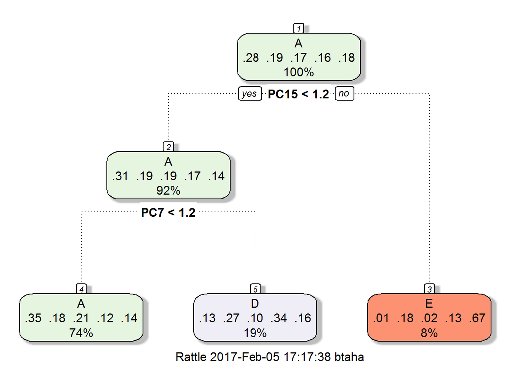

```r
fancyRpartPlot(model_rpart$finalModel)
```